# DL_project slides

# SVM (Support Vector Machine)

Support Vector Machine(SVM) is a supervised machine learning algorithm used for both classification and regression. Though we say regression problems as well its best suited for classification.  
The objective of SVM algorithm is to find a hyperplane in an N-dimensional space that distinctly classifies the data points.  
The dimension of the hyperplane depends upon the number of features. If the number of input features is two, then the hyperplane is just a line.  
If the number of input features is three, then the hyperplane becomes a 2-D plane. It becomes difficult to imagine when the number of features exceeds three.

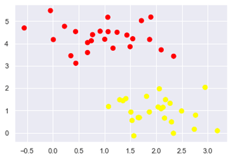

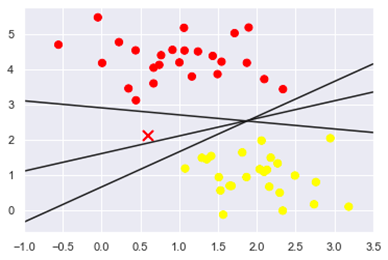

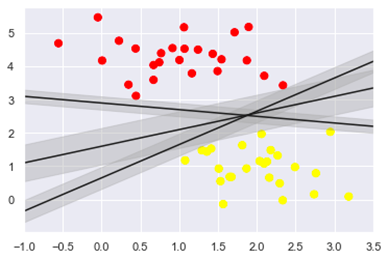

In support vector machines, the line that maximizes this margin is the one we will choose as the optimal model. Support vector machines are an example of such a maximum margin estimator.

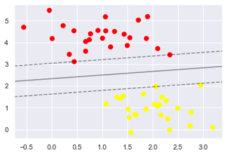

```
              precision    recall  f1-score   support

           0       0.82      0.81      0.81     40100
           1       0.81      0.82      0.82     39900

    accuracy                           0.82     80000
   macro avg       0.82      0.82      0.82     80000
weighted avg       0.82      0.82      0.82     80000
```

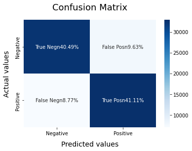

```python
SVCmodel = LinearSVC()
SVCmodel.fit(X_train, y_train)
model_Evaluate(SVCmodel)
y_pred2 = SVCmodel.predict(X_test)
```

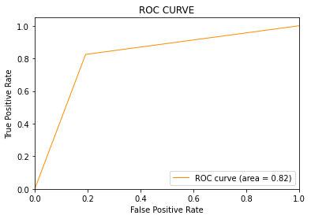

```python
ROC(y_test,y_pred2)
```

# Logistic Regression

Regression is a type of supervised learning which is used to predict outcomes based on the available data.  
Logistic Regression is a machine learning algorithm that allows us to create a classification model. The algorithm analyses one/more independent variables and one dependent variable, to predict the output.  
This algorithm is used to predict categorical variables using independent variables which are continuous. It identifies which of the target classes, a given entity belongs to. Here, the target classes are the possible outcome of the dependent variables. For example if the dependent variable has only 2 possible outcomes then there are two target classes.

Logistic Regression can classify entities into 2 or more classes based on the number of classes, the target values belong to. There are various types of logistic regression models:  
1) Binary classification: When there are only 2 possible outcomes, the classification is referred to as binary class classifier. This classification algorithm is best used for binary classification.  
2) Multi-class classification: If it has more than 2 classes, it's called multi-class classifier

The estimates the probability of an outcome and the value will be in between 0 or 1 (true or false).  
In binary class classification, for probability below 0.5 is considered as 0 (false) while more than 0.5 will be considered as 1 (true).  
The algorithm considers the natural log and the sigmoid functions to maintain the output values to be 0 or 1 only. Logistic Regression tries to fit the data to an S-shaped line,

# Activation function: Sigmoid

Sigmoid is a mathematical function that takes any real number and maps it to a probability between 1 and 0.

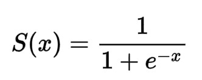

This is called a logistic/sigmoid function. This is also known as the logit or logistic function and is a multinomial expression.

### p = 1/1+e-(b0 + m1x1 + m2x2 + m3x3 + … … mnxn)

A hyperplane is used as a decision line to separate two categories (as far as possible) after data points have been assigned to a class using the Sigmoid function. The class of future data points can then be predicted using the decision boundary.

[figure not shown]